# Angewandte Statistik Bachelor of Science

Workshop Verteilungen von Wahrscheinlichkeiten

Patric Eichelberger

patric.eichelberger@bfh.ch

Bern University of Applied Sciences

10.09.2026

## Aufgabe 1

Ordne zu.

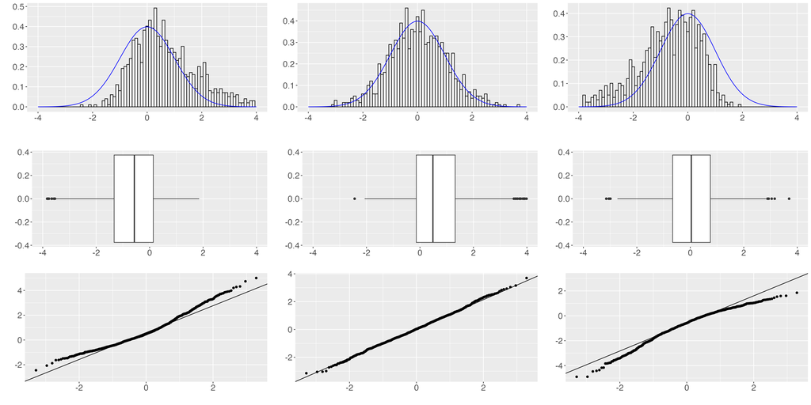

## Aufgabe 2

[figure not shown]

- Wie gross ist die gesamte Fläche unter der Standard-Normalverteilung?
- Wie gross ist die Fläche unter der Standard-Normalverteilung für $z \leq 0$?
- Wie gross ist die Fläche unter der Standard-Normalverteilung für $z \leq -1.96$?
- Wie gross ist die Fläche für $-1.96 \leq z \leq 1.96$?

## Aufgabe 3

Wahrscheinlichkeit der Normalverteilung.

Für diese Aufgabe verwenden wir das Modul **distrAction** in jamovi.

Das Körpergewicht sei normalverteilt mit Mittelwert 65 kg und Standardabweichung 5 kg.

Frage: Wie gross ist die Wahrscheinlichkeit zwischen 55 kg und 75 kg zu wiegen?

## Aufgabe 4

Wahrscheinlichkeit der Normalverteilung.

Für diese Aufgabe verwenden wir das Modul **distrAction** in jamovi.

Das Körpergewicht sei normalverteilt mit Mittelwert 65 kg und Standardabweichung 5 kg.

Frage: Wie gross ist die Wahrscheinlichkeit zwischen 62.5 kg und 72.8 kg zu wiegen?

## Aufgabe 5

- Benutze die Datei `NHANES-BW-BH.csv`
- Annahme: Normalverteilung mit Mittelwert und Standardabweichung des Körpergewichts in der vorliegenden Stichprobe.
- Wie schwer ist eine Person innerhalb des 95%-Normbereiches?
- Wie schwer muss eine Person mindestens sein, damit sie zu den 10% schwersten Personen gehört?
- Wie gross ist die Wahrscheinlichkeit, dass eine Person weniger oder 58 kg wiegt?
- Wie gross ist die Wahrscheinlichkeit, dass eine Person 58 kg oder mehr wiegt?